# t-SNE

Although Principal Component Analysis (PCA) proves effective for linear transformations, it often falls short in capturing the intricate non-linear relationships inherent in complex data structures. This limitation necessitates the exploration of more sophisticated techniques.

- t-Distributed Stochastic Neighbor Embedding (t-SNE) is a nonlinear dimensionality reduction technique primarily used for visualizing high-dimensional data.
- t-SNE is specifically engineered to visualize high-dimensional data in lower-dimensional spaces, typically two or three dimensions. By preserving crucial relationships and patterns within the data, t-SNE offers invaluable insights into the underlying structure of complex, multi-dimensional datasets. Their ability to reveal hidden patterns and clusters makes them indispensable tools for data scientists and researchers grappling with the challenges of high-dimensional data analysis.
- t-SNE constructs probability distributions over pairs of points in both the high-dimensional and low-dimensional spaces, then minimizes the difference between these distributions. As a result, points that are close in the original space tend to remain close in the reduced space, while maintaining a degree of separation between dissimilar points.

```python
import numpy as np
import matplotlib.pyplot as plt
import seaborn as sns
from sklearn.datasets import load_iris
from sklearn.manifold import TSNE
from sklearn.preprocessing import StandardScaler
```

```python
iris = load_iris()
X = iris.data
y = iris.target
```

Creating a t-SNE object with 2 dimensions. The hyperparameter, perplexity, balances local and global aspects of the data. It’s often set between 5 and 50. Smaller values emphasize local relationships while higher values indicate larger, more global patterns.

```python
scale = StandardScaler()
X_scaled = scale.fit_transform(X)
tsne = TSNE(n_components=2, random_state=617, perplexity=30, max_iter=1000)
X_tsne = tsne.fit_transform(X_scaled)
```

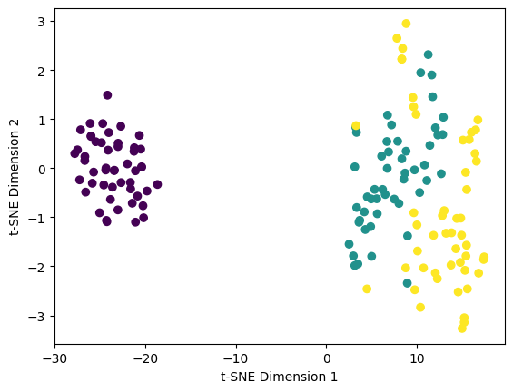

```python
plt.scatter(x = X_tsne[:,0], y = X_tsne[:,1], c = y, cmap = 'viridis')
plt.xlabel("t-SNE Dimension 1")
plt.ylabel("t-SNE Dimension 2")
```

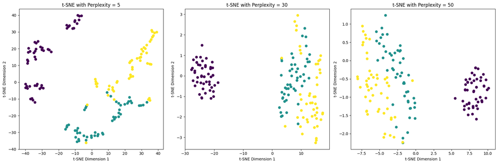

```python
perplexities = [5, 30, 50]
tsne_results = []
for perp in perplexities:
    tsne = TSNE(n_components=2, perplexity=perp, random_state=617)
    tsne_result = tsne.fit_transform(X_scaled)
    tsne_results.append(tsne_result)

plt.figure(figsize=(18, 6))
for i, perp in enumerate(perplexities):
    plt.subplot(1, 3, i+1)
    scatter = plt.scatter(tsne_results[i][:, 0], tsne_results[i][:, 1], c=y, cmap='viridis')
    plt.title(f"t-SNE with Perplexity = {perp}")
    plt.xlabel("t-SNE Dimension 1")
    plt.ylabel("t-SNE Dimension 2")
plt.tight_layout()
plt.show()
```

## Key Considerations for t-SNE

- Preservation of Local Structure: t-SNE excels at preserving local neighborhoods in the data. It focuses on maintaining the relationships between nearby points, ensuring that data points that are close in the high-dimensional space remain close in the lower-dimensional representation. However, this local focus can sometimes lead to distortions in the global structure of the data.
- Computational Complexity: t-SNE’s algorithm has a time complexity of O(n^2), where n is the number of data points. This quadratic scaling can make it computationally intensive, especially when dealing with large datasets.
- Perplexity Parameter: t-SNE introduces a crucial hyperparameter called perplexity, which significantly influences the balance between preserving local and global structure in the data visualization. The perplexity value can be interpreted as a smooth measure of the effective number of neighbors considered for each point. A smaller perplexity value (e.g., 5-10) emphasizes very local relationships, potentially revealing fine-grained structures but possibly missing larger patterns.

# Manifold Learning

A class of unsupervised estimators that seek to describe datasets as low-dimensional manifolds embedded in high-dimensional spaces. There are a number of manifold methods, including multidimensional scaling (MDS), locally linear embedding (LLE), and isometric mapping (Isomap). We will illustrate this method using isometric mapping.

```python
from sklearn.datasets import fetch_openml
from sklearn.model_selection import train_test_split
mnist = fetch_openml('mnist_784',as_frame=False)
X = mnist.data
y = mnist.target
X_train, X_test, y_train, y_test = train_test_split(X, y, test_size=0.3, random_state=1031)
```

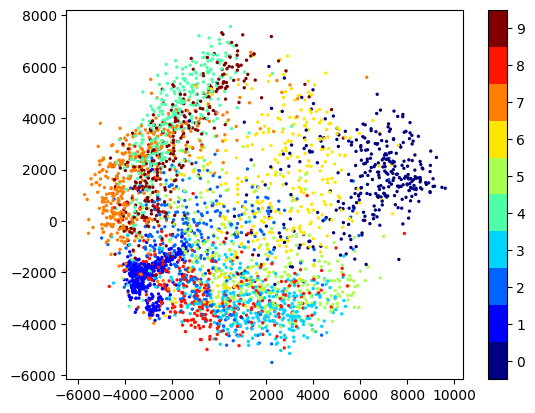

```python
from sklearn.manifold import Isomap
model = Isomap(n_components=2)
data = X[::20]
target = y[::20]
model = Isomap(n_components=2)
proj = model.fit_transform(data)
import matplotlib.pyplot as plt
import seaborn as sns
plt.scatter(proj[:, 0], proj[:, 1], c=target.astype(int), cmap=plt.get_cmap('jet', 10),s=2)
plt.colorbar(ticks=range(10))
plt.clim(-0.5, 9.5);
```

This file was generated using Python 3.13.5 on Windows 10 with the following libraries: matplotlib 3.10.3, numpy 2.3.1, pandas 2.3.0, scikit-learn 1.7.1, seaborn 0.13.2